# Graphs in Python: Boxplots with One Group of Data *without using axes objects*

⇦ Back

For this page we will use data from the finals of various Olympic events, available on Wikipedia.

# 1 Data Formats

Boxplots using Matplotlib in Python can take data in the form of a **list-of-lists**:

```python
# Results from the men's long jump finals of four Olympic games
data = [
    [8.59, 8.47, 8.32, 8.31, 8.25, 8.24, 8.23, 8.21],
    [8.34, 8.24, 8.20, 8.19, 8.19, 8.16, 8.07, 8.00],
    [8.31, 8.16, 8.12, 8.11, 8.10, 8.07, 8.01, 7.93],
    [8.38, 8.37, 8.29, 8.25, 8.17, 8.10, 8.06, 8.05]
]
labels = ['Athens 2004', 'Beijing 2008', 'London 2012', 'Rio 2016']
```

But it is often easier to use a Pandas **data frame** that you first convert into a Numpy **array**:

```python
import pandas as pd
import numpy as np

# Results from the men's long jump finals of four Olympic games
data = pd.DataFrame({
    'Athens 2004': [8.59, 8.47, 8.32, 8.31, 8.25, 8.24, 8.23, 8.21],
    'Beijing 2008': [8.34, 8.24, 8.20, 8.19, 8.19, 8.16, 8.07, 8.00],
    'London 2012': [8.31, 8.16, 8.12, 8.11, 8.10, 8.07, 8.01, 7.93],
    'Rio 2016': [8.38, 8.37, 8.29, 8.25, 8.17, 8.10, 8.06, 8.05]
})
# You can use the column headings from the data frame as labels
labels = list(data)
# A data frame needs to be converted into an array before it can be plotted this way
data = np.array(data)
```

Both of these methods will work with the code that follows. However, the advantage of using a data frame is that it is a more useful format for doing data manipulation in general.

# 2 A Simple Boxplot

The plotting is going to be done using one function: `boxplot()` from the Matplotlib library. Specifically, it comes from the pyplot module within the Matplotlib library, so that can be imported and given the shorthand name **plt**:

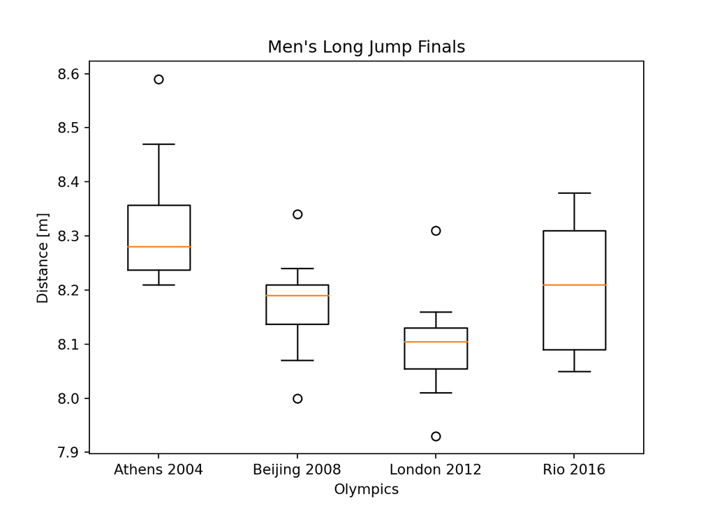

```python
import matplotlib.pyplot as plt

plt.boxplot(data, labels=labels)
plt.title("Men's Long Jump Finals")
plt.ylabel('Distance [m]')
plt.xlabel('Olympics')
```

Note that this method is robust to the number of datasets you have. We could easily comment out some of the sets of results (or add more) and still have it work.

# 3 Improving the Format

We’re going to make a number of formatting changes to improve how this graph looks:

- Make the figure size A6 (see here for more info)
- Use Latex for the labels (see here for more info)
- Edit the boxplot itself to:
  - Remove fliers (`sym=''`)
  - Extend the whiskers to cover the whole range of the data (`whis=[0, 100]`)
  - Change the widths (`widths=0.4`)
- Change the y-axis limits (`ylim()`)
- Turn minor tick markers on (`minorticks_on()`)
- Customise the positions of the minor tick markers on the x-axis with `plt.gca().xaxis.set_minor_locator()` so as to position a tick on either side of each of the x-axis labels (`np.array(range(len(labels) + 1)) + 0.5`)
- Make the minor ticks visible (`plt.gca().tick_params(axis='x', which='minor', length=4)`)
- Make the major ticks invisible (`plt.gca().tick_params(axis='x', which='major', length=0)`)

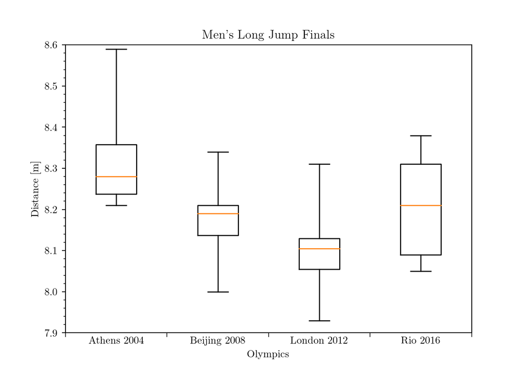

```python
import matplotlib.ticker as ticker

# Make figures A6
A = 6
plt.rc('figure', figsize=[46.82 * .5**(.5 * A), 33.11 * .5**(.5 * A)])
# Use Latex
plt.rc('text', usetex=True)
plt.rc('font', family='serif')

# Plot
plt.boxplot(data, sym='', whis=[0, 100], widths=0.4, labels=labels)
plt.title("Men's Long Jump Finals")
plt.ylabel('Distance [m]')
plt.ylim(7.9, 8.6)
plt.xlabel('Olympics')
plt.minorticks_on()
plt.gca().xaxis.set_minor_locator(ticker.FixedLocator(
    np.array(range(len(labels) + 1)) + 0.5
))
plt.gca().tick_params(axis='x', which='minor', length=4)
plt.gca().tick_params(axis='x', which='major', length=0)

plt.show()
```

# 4 Change the Colours

It might be cool to colour each boxplot in the colours of the host country. Let’s see how to do that:

- When calling `boxplot()` you need to add `patch_artist=True` and assign the output of the function to a variable `bp` which creates a **boxplot object**
- The colours of the lines of the boxplots are controlled with `setp()`:
  - `setp(bp['boxes'], color='red')` will set the box outlines to red
  - `setp(bp['boxes'], facecolor='red')` will set the box fills to red
  - `setp(bp['medians'], color='red')` will set the median lines to red
  - `setp(bp['whiskers'], color='red')` will set the vertical whiskers to red
  - `setp(bp['caps'], color='red')` will set the horizontal caps to red

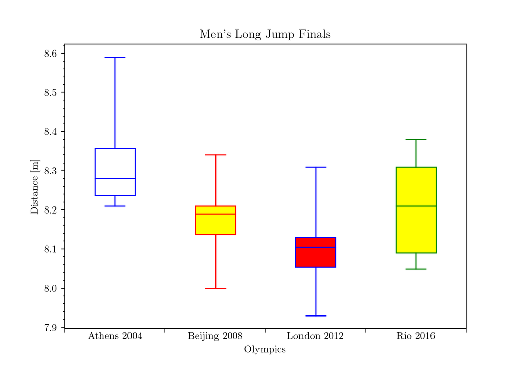

```python
# Plot
bp = plt.boxplot(
    data, sym='', whis=[0, 100], widths=0.4, labels=labels, patch_artist=True
)
# Axis details
plt.title("Men's Long Jump Finals")
plt.ylabel('Distance [m]')
plt.xlabel('Olympics')
plt.minorticks_on()
plt.gca().xaxis.set_minor_locator(ticker.FixedLocator(
    np.array(range(len(labels) + 1)) + 0.5
))
plt.gca().tick_params(axis='x', which='minor', length=4)
plt.gca().tick_params(axis='x', which='major', length=0)
# Colour the outlines
colours = ['blue', 'red', 'blue', 'green']
for i, box in enumerate(bp['boxes']):
    # Iterate over the colours
    j = i % len(colours)
    # Set the colour of the boxes' outlines
    plt.setp(bp['boxes'][i], color=colours[j])
    # Set the colour of the median lines
    plt.setp(bp['medians'][i], color=colours[j])
    # Set the colour of the lower whiskers
    plt.setp(bp['whiskers'][2 * i], color=colours[j])
    # Set the colour of the upper whiskers
    plt.setp(bp['whiskers'][2 * i + 1], color=colours[j])
    # Set the colour of the lower caps
    plt.setp(bp['caps'][2 * i], color=colours[j])
    # Set the colour of the upper caps
    plt.setp(bp['caps'][2 * i + 1], color=colours[j])
# Fill the boxes with colours (requires patch_artist=True)
colours = ['white', 'yellow', 'red', 'yellow']
for i, box in enumerate(bp['boxes']):
    # Iterate over the colours
    j = i % len(colours)
    # Set the colour of the box
    plt.setp(bp['boxes'][i], facecolor=colours[j])

plt.show()
```

Unfortunately, that doesn’t look so good, so we’ll remove it going forward and just keep the fill colour and the median line colour.

# 5 Show the Median Values on the Plot

It’s pretty useful to be able to see the median values of each dataset right there on the graph, and this feature can be added by using the `text()` function.

- Get the median value of each dataset with `bp['medians'][i].get_ydata()[0]`
- Round the medians off to two decimal places and convert them to strings (so they can easily be used as text labels) using `str(round(s, 2))`
- The x-positions for the text annotations are the same as the x-positions of the boxplots themselves (ie 1, 2, 3, 4) so you can use `np.arange(len(data)) + 1`
- The y-position of the annotations is a little bit more tricky. You first want to extend the plot downwards to create space for the text, and when you do this you should use a percent (eg increase the height by 5%) rather than a nominal amount in order for the code to be robust to any set of data. This way, every graph you plot will have a consistent 5% more space for text regardless of what actual numbers you are using.
- Create the annotations with `text(x_pos, y_pos, 'text')`

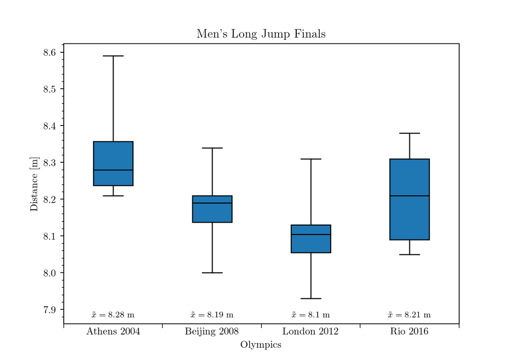

```python
#
# Plot
#
bp = plt.boxplot(
    data, sym='', whis=[0, 100], widths=0.4, labels=labels, patch_artist=True
)
# Axis details
plt.title("Men's Long Jump Finals")
plt.ylabel('Distance [m]')
plt.xlabel('Olympics')
plt.minorticks_on()
plt.gca().xaxis.set_minor_locator(ticker.FixedLocator(
    np.array(range(len(labels) + 1)) + 0.5
))
plt.gca().tick_params(axis='x', which='minor', length=4)
plt.gca().tick_params(axis='x', which='major', length=0)
# Set the fill colour
plt.setp(bp['boxes'], facecolor='C0')
# Set the colour of the median lines
plt.setp(bp['medians'], color='black')

#
# Annotate the medians
#
# Get the samples' medians
medians = [bp['medians'][i].get_ydata()[0] for i in range(len(labels))]
medians = [str(round(s, 2)) for s in medians]
# Get the x-positions for the labels
x_pos = np.arange(len(labels)) + 1
# Get the y-axis limits and range
y_lim = plt.ylim()
y_range = y_lim[1] - y_lim[0]
# Increase the height of the plot by 5% to fit the labels
plt.ylim([y_lim[0] - 0.05 * y_range, y_lim[1]])
# Set the y-positions for the labels
y_pos = y_lim[0] - 0.025 * y_range
# Create the annotations
for i in range(len(labels)):
    k = i % 2
    plt.text(
        x_pos[i], y_pos, r'$\tilde{x} =' + fr' {medians[i]}$ m',
        horizontalalignment='center', size='small'
    )
```

## 5.1 Show Median Values *AND* Sample Sizes

As you start adding more annotations to the plot area you quickly begin to run out of space. As a result, it sometimes makes more sense to add theses labels *above* the boxes instead of below them:

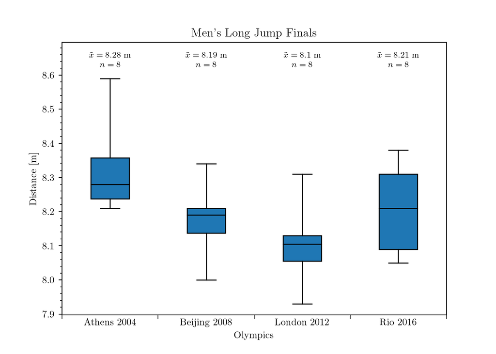

```python
#
# Plot
#
bp = plt.boxplot(
    data, sym='', whis=[0, 100], widths=0.4, labels=labels, patch_artist=True
)
# Axis details
plt.title("Men's Long Jump Finals")
plt.ylabel('Distance [m]')
plt.xlabel('Olympics')
plt.minorticks_on()
plt.gca().xaxis.set_minor_locator(ticker.FixedLocator(
    np.array(range(len(labels) + 1)) + 0.5
))
plt.gca().tick_params(axis='x', which='minor', length=4)
plt.gca().tick_params(axis='x', which='major', length=0)
# Set the fill colour
plt.setp(bp['boxes'], facecolor='C0')
# Set the colour of the median lines
plt.setp(bp['medians'], color='black')
# Get the samples' medians and sizes
medians = [bp['medians'][i].get_ydata()[0] for i in range(len(labels))]
medians = [str(round(s, 2)) for s in medians]
sample_sizes = [data.shape[0] for i in range(len(labels))]
sample_sizes = [f'{s:,}' for s in sample_sizes]
# Get the x-positions for the labels
x_pos = np.arange(len(labels)) + 1
# Get the y-axis limits and range
y_lim = plt.ylim()
y_range = y_lim[1] - y_lim[0]
# Increase the height of the plot by 10% to fit the labels
plt.ylim([y_lim[0], y_lim[1] + 0.10 * y_range])
# Set the y-positions for the median labels
y_pos = y_lim[1] + 0.04 * y_range
# Create the annotations for the medians
for i in range(len(labels)):
    k = i % 2
    plt.text(
        x_pos[i], y_pos, r'$\tilde{x} =' + fr' {medians[i]}$ m',
        horizontalalignment='center', size='small'
    )
# Set the y-positions for the sample size labels
y_pos = y_lim[1]
# Create the annotations for the sample sizes
for i in range(len(labels)):
    k = i % 2
    plt.text(
        x_pos[i], y_pos, r'$n =' + fr' {sample_sizes[i]}$',
        horizontalalignment='center', size='small'
    )
```

# 6 Add Gridlines

Gridlines can aid in interpreting a graph.

- Show the major axis gridlines using `grid()`
- Plot horizontal lines using `axhline()`

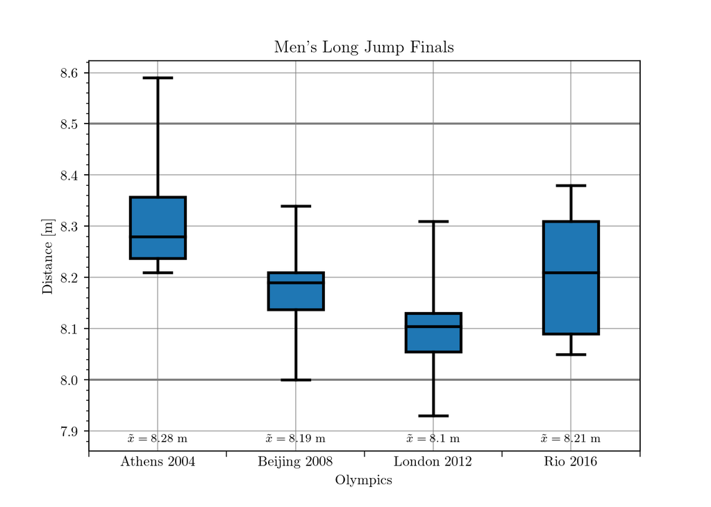

```python
#
# Plot
#
bp = plt.boxplot(
    data, sym='', whis=[0, 100], widths=0.4, labels=labels,
    patch_artist=True
)
# Axis details
plt.title("Men's Long Jump Finals")
plt.ylabel('Distance [m]')
plt.xlabel('Olympics')
plt.minorticks_on()
plt.gca().xaxis.set_minor_locator(ticker.FixedLocator(
    np.array(range(len(labels) + 1)) + 0.5
))
plt.gca().tick_params(axis='x', which='minor', length=4)
plt.gca().tick_params(axis='x', which='major', length=0)
# Set the fill colour
plt.setp(bp['boxes'], facecolor='C0', lw=2)
# Set the colour of the median lines
plt.setp(bp['medians'], color='black', lw=2)
# Set the width of the whiskers
plt.setp(bp['whiskers'], lw=2)
# Set the width of the caps
plt.setp(bp['caps'], lw=2)
# Lines
plt.grid(color='grey', alpha = 0.6)
plt.axhline(8, color='grey', zorder=1)
plt.axhline(8.5, color='grey', zorder=1)
# Get the samples' medians
medians = [bp['medians'][i].get_ydata()[0] for i in range(len(labels))]
medians = [str(round(s, 2)) for s in medians]
# Get the x-positions for the labels
x_pos = np.arange(len(labels)) + 1
# Get the y-axis limits and range
y_lim = plt.ylim()
y_range = y_lim[1] - y_lim[0]
# Increase the height of the plot by 5% to fit the labels
plt.ylim([y_lim[0] - 0.05 * y_range, y_lim[1]])
# Set the y-positions for the labels
y_pos = y_lim[0] - 0.025 * y_range
# Create the annotations
for i in range(len(labels)):
    k = i % 2
    plt.text(
        x_pos[i], y_pos, r'$\tilde{x} =' + fr' {medians[i]}$ m',
        horizontalalignment='center', size='small'
    )
```

# 7 Subplots

The easiest way to plots multiple graphs that all have the same format is to create a function and call that repeatedly on each dataset. Some changes do need to be made, however:

First, create the data:

```python
import pandas as pd
import matplotlib.pyplot as plt
import numpy as np

# Long jump
long_jump_men = pd.DataFrame({
    'Athens 2004': [8.59, 8.47, 8.32, 8.31, 8.25, 8.24, 8.23, 8.21],
    'Beijing 2008': [8.34, 8.24, 8.20, 8.19, 8.19, 8.16, 8.07, 8.00],
    'London 2012': [8.31, 8.16, 8.12, 8.11, 8.10, 8.07, 8.01, 7.93],
    'Rio 2016': [8.38, 8.37, 8.29, 8.25, 8.17, 8.10, 8.06, 8.05]
})
long_jump_women = pd.DataFrame({
    'Athens 2004': [7.07, 7.05, 7.05, 6.96, 6.85, 6.83, 6.80, 6.73],
    'Beijing 2008': [7.04, 7.03, 6.91, 6.79, 6.76, 6.70, 6.64, 6.58],
    'London 2012': [7.12, 7.07, 6.89, 6.88, 6.77, 6.76, 6.72, 6.67],
    'Rio 2016': [7.17, 7.15, 7.08, 6.95, 6.81, 6.79, 6.74, 6.69]
})
# Shot put
shot_put_men = pd.DataFrame({
    'Athens 2004': [21.16, 21.16, 21.07, 20.84, 20.60, 20.34, 20.31, 20.26],
    'Beijing 2008': [21.51, 21.09, 21.05, 21.04, 20.98, 20.63, 20.53, 20.42],
    'London 2012': [21.89, 21.86, 21.23, 21.19, 20.93, 20.84, 20.71, 20.69],
    'Rio 2016': [22.52, 21.78, 21.36, 21.20, 21.02, 20.72, 20.64, 20.64]
})
shot_put_women = pd.DataFrame({
    'Athens 2004': [21.06, 19.59, 19.55, 19.49, 19.01, 18.96, 18.64, 18.59],
    'Beijing 2008': [20.56, 20.28, 19.86, 19.50, 19.20, 19.08, 19.01, 19.00],
    'London 2012': [21.36, 20.70, 20.48, 20.22, 19.63, 19.42, 19.18, 19.02],
    'Rio 2016': [20.63, 20.42, 19.87, 19.39, 19.35, 19.03, 18.37, 18.23]
})
# Javelin
javelin_men = pd.DataFrame({
    'Athens 2004': [86.50, 84.95, 84.84, 84.13, 83.31, 83.25, 83.14, 83.01],
    'Beijing 2008': [90.57, 86.64, 86.16, 83.95, 83.46, 83.45, 83.15, 82.06],
    'London 2012': [84.58, 84.51, 84.12, 83.34, 82.80, 82.63, 81.91, 81.21],
    'Rio 2016': [90.30, 88.24, 85.38, 85.32, 83.95, 83.05, 82.51, 82.42]
})
javelin_women = pd.DataFrame({
    'Athens 2004': [71.53, 65.82, 64.29, 64.23, 63.54, 62.77, 62.51, 61.75],
    'Beijing 2008': [71.42, 70.78, 66.13, 65.75, 65.29, 63.35, 62.02, 59.64],
    'London 2012': [69.55, 65.16, 64.91, 64.53, 63.70, 62.89, 61.62, 60.73],
    'Rio 2016': [66.18, 64.92, 64.80, 64.78, 64.60, 64.36, 64.04, 62.92]
})
# Collate
data = [
    np.array(long_jump_men), np.array(long_jump_women), np.array(shot_put_men),
    np.array(shot_put_women), np.array(javelin_men), np.array(javelin_women)
]
labels = [
    list(long_jump_men), list(long_jump_women), list(shot_put_men),
    list(shot_put_women), list(javelin_men), list(javelin_women)
]
titles = [
    "Men's Long Jump", "Women's Long Jump",
    "Men's Shot Put", "Women's Shot Put",
    "Men's Javelin", "Women's Javelin",
]
```

Now plot it:

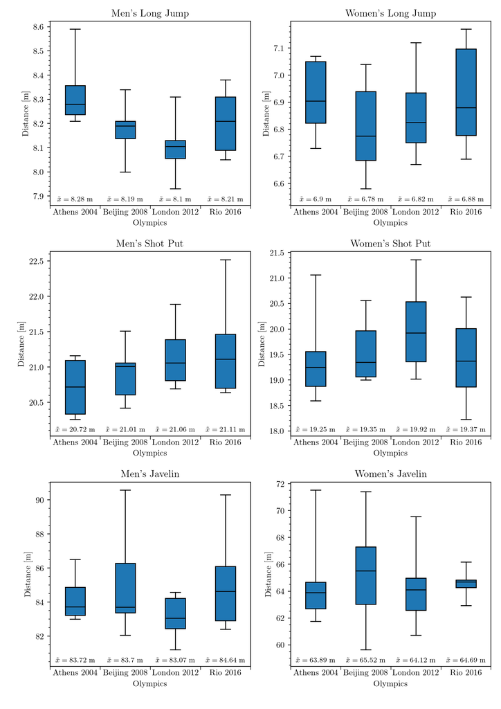

```python
# Make the figure A4
A = 4
plt.rc('figure', figsize=[33.11 * .5**(.5 * A), 46.82 * .5**(.5 * A)])


def plot_boxplots(data, labels, title):
    """Plot multiple boxplots."""
    bp = plt.boxplot(
        data, sym='', whis=[0, 100], widths=0.4, labels=labels,
        patch_artist=True
    )
    # Axis details
    plt.title(title)
    plt.ylabel('Distance [m]')
    plt.xlabel('Olympics')
    plt.minorticks_on()
    plt.gca().xaxis.set_minor_locator(ticker.FixedLocator(
        np.array(range(len(labels) + 1)) + 0.5
    ))
    plt.gca().tick_params(axis='x', which='minor', length=4)
    plt.gca().tick_params(axis='x', which='major', length=0)
    # Set the fill colour
    plt.setp(bp['boxes'], facecolor='C0')
    # Set the colour of the median lines
    plt.setp(bp['medians'], color='black')
    # Get the samples' medians
    medians = [bp['medians'][i].get_ydata()[0] for i in range(len(labels))]
    medians = [str(round(s, 2)) for s in medians]
    # Get the x-positions for the labels
    x_pos = np.arange(len(labels)) + 1
    # Get the y-axis limits and range
    y_lim = plt.ylim()
    y_range = y_lim[1] - y_lim[0]
    # Increase the height of the plot by 5% to fit the labels
    plt.ylim([y_lim[0] - 0.05 * y_range, y_lim[1]])
    # Set the y-positions for the labels
    y_pos = y_lim[0] - 0.025 * y_range
    # Create the annotations
    for i in range(len(labels)):
        k = i % 2
        plt.text(
            x_pos[i], y_pos, r'$\tilde{x} =' + fr' {medians[i]}$ m',
            horizontalalignment='center', size='small'
        )


# Call function
for i, v in enumerate(range(321, 327)):
    plt.subplot(v)
    plot_boxplots(data[i], labels[i], titles[i])
plt.subplots_adjust(
    left=0.1, right=0.98, top=0.97, bottom=0.06, wspace=0.2, hspace=0.25
)

plt.show()
```

⇦ Back